# Dice blog

### Testing sketchy dice

I bought a backgammon set in the grand bazaar in Istanbul It's a beautiful board with mother of perl inlays, carvings, and brass accents, but the dice that came with it were tiny and ugly, and don’t seem fair. As we all know humans are terrible at assessing the fairness of things like dice. We just get excited about double sixes and runs of low numbers and remember those things while ignoring the mundane.

So I rolled the two weird dice 100 times each. After spending that quality time with them I decided they should be named Chunky 1, because it’s got about twice as much red paint on the one side as on any other side, and Messy 6 because the six side is all messed up

For comparison I used `np.random.randint(1,6+1,100)` to trow a 'fair' dice 100 times, but I did not bond with that dice, it will just be named Fair.

```python
import numpy as np


d1 = [6,1,5,6,6,1,3,6,4,2,5,5,5,1,2,6,2,6,1,2,1,6,1,1,5,5,1,6,1,1,2,3,1,5,2,2,5,1,1,1,1,3,2,1,1,4,6,2,6,3,3,1,6,6,1,5,5,5,6,3,6,4,4,4,6,2,6,5,3,4,1,6,5,1,6,3,1,1,3,2,5,6,3,4,6,6,5,4,3,6,2,6,5,1,5,1,2,6,1,1,]
d2 = [6,4,1,6,6,6,1,6,3,1,6,2,2,4,3,6,1,5,5,4,5,5,3,4,2,1,4,2,3,6,2,5,5,1,1,1,1,4,2,6,3,1,1,1,3,1,3,6,1,2,5,6,1,1,5,6,6,2,4,5,5,5,2,1,1,3,1,5,2,1,2,5,6,1,3,2,3,6,2,5,1,5,4,2,2,1,6,1,5,4,4,2,1,6,4,2,5,2,6,3]
df = np.random.randint(1,6+1,100)

#Checking the counts
print len(d1);print len(d2);print len(df)
```

```
100
100
100
```

### Here's the disturibution of all the throws

```python
import pandas as pd
dice = pd.DataFrame({"Messy_6":d1,"Chunky_1":d2,"Fair":df})
dice.describe()
```

|  | Chunky_1 | Fair | Messy_6 |
| --- | --- | --- | --- |
| count | 100.000000 | 100.000000 | 100.000000 |
| mean | 3.310000 | 3.430000 | 3.470000 |
| std | 1.878614 | 1.718909 | 1.987105 |
| min | 1.000000 | 1.000000 | 1.000000 |
| 25% | 1.750000 | 2.000000 | 1.000000 |
| 50% | 3.000000 | 3.000000 | 3.000000 |
| 75% | 5.000000 | 5.000000 | 5.000000 |
| max | 6.000000 | 6.000000 | 6.000000 |

This is where we would consier the mean and standard deveation to start to get a sense of weather the dice are fair, but as you will see, a sample size of 100 is actualy pretty meaningless.

But since we're hear might as well make a nice visualization:

```python
%matplotlib inline
import seaborn as sns
import matplotlib.pyplot as plt

# How many times each number was rolled, for all three dice
counts = pd.concat([dice.Chunky_1.value_counts().sort_index(),
                    dice.Messy_6.value_counts().sort_index(),
                    dice.Fair.value_counts().sort_index()],
                    axis=1)

counts.index.name = 'Roll'

counts[['Chunky_1','Fair','Messy_6']]
```

| Roll | Chunky_1 | Fair | Messy_6 |
| --- | --- | --- | --- |
| 1 | 25 | 16 | 27 |
| 2 | 18 | 22 | 13 |
| 3 | 11 | 15 | 11 |
| 4 | 11 | 11 | 8 |
| 5 | 17 | 22 | 17 |
| 6 | 18 | 14 | 24 |

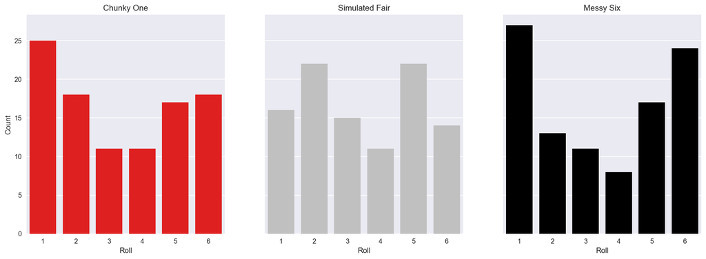

```python
%matplotlib inline
%config InlineBackend.figure_format = 'retina'

# Make three graphes in a one by three grid
fig, ax = plt.subplots(1,3,sharey=True)
fig.set_size_inches(18,6)

c1 = sns.barplot(x=counts.index, y='Chunky_1', data=counts, color='red', ax=ax[0])
c1.set_title("Chunky One")
c1.set_ylabel("Count")

f = sns.barplot(x=counts.index, y='Fair', data=counts, color='silver', ax=ax[1])
f.set_title("Simulated Fair")
f.set_ylabel("")

m6 = sns.barplot(x=counts.index, y='Messy_6', data=counts, color='black', ax=ax[2])
m6.set_title("Messy Six")
m6.set_ylabel("")
```

Even with the assistance of numpy, pandas, and seaborne at 100 observations it's hard to tell *visually* if the die are really off, or if the sample is random. So lets get a t test up in here to help us out.

FYI: The greater the magnitude of T (it can be either positive or negative), the greater the evidence against the null hypothesis that there is no significant difference. The closer T is to 0, the more likely there isn't a significant difference. -[Mini tab blog](http://blog.minitab.com/blog/statistics-and-quality-data-analysis/what-are-t-values-and-p-values-in-statistics)

```python
from scipy import stats
```

```python
# How different is Chunky One from our Fair die?
stats.ttest_rel(dice.Chunky_1,dice.Fair)
```

```
Ttest_relResult(statistic=-0.43934526676811081, pvalue=0.66136887050090398)
```

```python
# How different is Messy Six from our Fiair data?
stats.ttest_rel(dice.Messy_6,dice.Fair)
```

```
Ttest_relResult(statistic=0.15612568919319297, pvalue=0.87625187145469985)
```

```python
# How different is Chunky One from Messy Six?
stats.ttest_rel(dice.Chunky_1,dice.Messy_6)
```

```
Ttest_relResult(statistic=-0.55749576721449801, pvalue=0.57844712809499366)
```

Based on the t test for messy 6 it might be close to fair! But that P value shows us that with 100 samples no decent publication would touch that finding!

The moral of the story is: n=100 is not enough to know if these dice are fair or not!

http://hamelg.blogspot.com/2015/11/python-for-data-analysis-part-25-chi.html

https://www.youtube.com/watch?v=7MwsZaQxLKQ